# Robust and resistance regression

# 1 Theory

Based on https://socserv.socsci.mcmaster.ca/jfox/Books/Companion/appendix/Appendix-Robust-Regression.pdf

## 1.1 M-Estimation

The most common general method of robust regression is M-estimation, introduced by Huber (1964). This class of estimators can be regarded as a generalization of maximum-likelihood estimation, hence the “M”. Although M estimators are not robust with respect to leverage points, they are popular in applications where leverage points are not an issue.

We consider only the linear model

$$y_i = \boldsymbol{x}_i'\boldsymbol{\beta} + \epsilon_i$$
for the $i$-th observation of $n$ independent observations. We assume that the model itself is not at issue, $E(y |\boldsymbol{x}) = \boldsymbol{x}_i'\boldsymbol{\beta}$, but the distribution of the errors may be heavy-tailed, producing occasional outliers.

Residuals are given by

$$e_i = y_i - \hat{y}_i = y_i - \boldsymbol{x}_i'\boldsymbol{b}$$
In M -estimation, the estimates $\boldsymbol{b}$ are determined by minimizing a particular objective function over all $\boldsymbol{b}$.

$$\sum_{i=1}^n\rho(e_i) = \sum_{i=1}^n\rho(y_i - \boldsymbol{x}_i'\boldsymbol{b}),$$

where function $\rho$ should have the following properties:

- always-non negative,
- $\rho(0) = 0$,
- symmetric – $\rho(-e) = \rho(e)$,
- monotone in $|e_i|$, $\rho(e_i) \geq \rho(e_i')$ for $|e_i| \geq |e_i'|$

For example, the least-squares $\rho(e_i) = e_i^2$ satisfies these requirements, as do many other functions.

## 1.2 Computing of M-estimates

The minimum value of Equation 1 can be found by differentiating with respect to the argument b, and setting the resulting partial derivatives to

$$\boldsymbol{0} = \frac{\partial}{\partial \boldsymbol{b}} \sum_{i=1}^{n}\rho(y_i - \boldsymbol{x}_i^\prime\boldsymbol{b}) = \sum_{i=1}^n\psi(y_i - \boldsymbol{x}_i'\boldsymbol{b})\boldsymbol{x}_i'$$
where the influence curve $\psi$ is is defined to be the derivative of $\rho$ with respect to its argument.

To facilitate computing, we would like to make this last equation similar to the estimating equations for a familiar problem like weighted least squares. To this end, define the weight function $w_i=w(e_i)=\psi(e_i)/e_i$

$$\sum_{i=1}^nw(y_i - \boldsymbol{x}_i'\boldsymbol{b})\boldsymbol{x}_i' = \boldsymbol{0}$$
An iterative solution (called iteratively reweighted least-squares, IRLS) is therefore required:

1. Select initial estimates $\boldsymbol{b}^{0}$, such as the least-squares estimates.
2. At each iteration $t$, calculate residuals $e_i^{(t-1)}$ and associated weights $w_i^{(t-1)}=w\left[e_i^{t=1} \right]$.
3. Solve for new weighted-least-squares estimates

$$\boldsymbol{b}^{(t)} = \left[\boldsymbol{X}'\boldsymbol{W}^{(t-1)}\boldsymbol{X}\right]^{-1}\boldsymbol{X}'\boldsymbol{W}^{(t-1)}\boldsymbol{y},$$

where $\boldsymbol{X}$ is the model matrix, with $\boldsymbol{x}_i'$ as its $i$th row, and $\boldsymbol{W}^{(t-1)} = diag\left\{ w_{i}^{t-1}\right\}$ in the current weight matrix.

Steps 2 and 3 are repeated until the estimated coefficients converge.

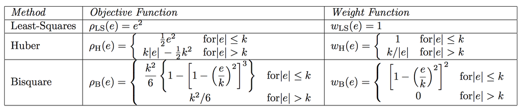

objective functions

Inne funkcje – http://support.sas.com/documentation/cdl/en/statug/68162/HTML/default/viewer.htm#statug_rreg_details01.htm#statug.rreg.robustregfweightfunction

# 2 Bounded-Influence Regression

Under certain circumstances, M-estimators can be vulnerable to high-leverage observations. Very- high-breakdown bounded-influence estimators for regression have been proposed.

The breakdown value of an estimator is the smallest contamination fraction of the data that can cause the estimates on the entire data to be arbitrarily far from the estimates on only the uncontaminated data. The breakdown value of an estimator can be used to measure the robustness of the estimator. Rousseeuw and Leroy (1987) and others introduced the following high breakdown value estimators for linear regression.

One bounded-influence estimator is least-trimmed squares (LTS) regression. Order the squared residuals from smallest to largest

$$(e^2)_{(1)},(e^2)_{(2)},...,(e^2)_{(n)}$$

The LTS estimator chooses the regression coefficients $\boldsymbol{b}$ to minimize the sum of the smallest $m$ of the squared residuals.

$$LTS(\boldsymbol{b}) = \sum_{i=1}^m(e^2)_{(i)},$$
where typicaly $m = \lfloor n/2 \rfloor + \lfloor (k+2)/2 \rfloor$. While the LTS criterion is easily described, the mechanics of fitting the LTS estimator are complicated. Moreover, bounded-influence estimators can produce unreasonable results in certain circumstances and there is no simple formula for coefficient standard errors.

## 2.1 MM-Estimation

One application of bounded-influence estimators is to provide starting values for M-estimation. This procedure, along with using the bounded-influence estimate of the error variance, produces the so-called MM-estimator. The MM -estimator retains the high breakdown point of the bounded- influence estimator and shares the relatively high efficiency under normality of the traditional M -estimator. MM -estimators are especially attractive when paired with redescending 𝜓-functions such as the bisquare, which can be sensitive to starting values.

## 2.2 Methods available in R packages

- MASS::lqs, method:
  - lts,
  - lqs,
  - lms,
  - S

# 3 Example

Packages

```r
library(MASS)
library(robust)
library(robustbase)
```

Functions:

- MASS:rlm – robust linear regession (e.g. the Huber M-estimator)

```r
rema <- read.csv2('../data-raw/project_data_train.csv',
                 header = T,
                 stringsAsFactors = F,
                 dec = '.')
rema
```

| dwelling_id | trans_date | trans_dwelling_rooms | trans_dwelling_floor_area | trans_dwelling_storey | trans_dwelling_spaces | trans_dwelling_spaces_floor_area | trans_dwelling_price | trans_dwelling_price_m2 | lon | lat | pzn_precinct | pzn_district |
| --- | --- | --- | --- | --- | --- | --- | --- | --- | --- | --- | --- | --- |
| 03836_02325 | 2008-01-02 | 3 | 49.60 | NA | NA | NA | 275000 | 5544.35 | 16.88764 | 52.39359 | Sw. Lazarz | Grunwald |
| 05998_10489 | 2008-01-02 | 3 | 46.90 | NA | NA | NA | 260000 | 5543.71 | 16.96162 | 52.40953 | Ostrow Tumski-Srodka-Zawady-Komandoria | Stare Miasto |
| 00037_10997 | 2008-01-02 | 4 | 67.39 | NA | 1 | 7.40 | 150000 | 2225.85 | 16.98832 | 52.41176 | Warszawskie-Pomet-Maltanskie | Stare Miasto |
| 00038_11098 | 2008-01-02 | 2 | 34.70 | 0 | 4 | 20.30 | 120000 | 3458.21 | 16.99000 | 52.40756 | Warszawskie-Pomet-Maltanskie | Stare Miasto |
| 08962_00377 | 2008-01-03 | 5 | 79.35 | 2 | NA | NA | 150000 | 1890.36 | 16.92508 | 52.42468 | Stare Winogrady | Nowe Miasto |
| 04164_01761 | 2008-01-03 | 7 | 180.00 | NA | NA | NA | 950000 | 5277.78 | 16.89761 | 52.39879 | Sw. Lazarz | Grunwald |
| 08031_01920 | 2008-01-03 | 4 | 51.60 | 2 | NA | 9.40 | 464400 | 9000.00 | 16.93825 | 52.40579 | Stare Miasto | Nowe Miasto |
| 01043_02109 | 2008-01-03 | 1 | 35.70 | NA | NA | NA | 210000 | 5882.35 | 16.89849 | 52.41908 | Jezyce | Jezyce |
| 05366_02926 | 2008-01-03 | 2 | 26.40 | NA | NA | NA | 320000 | 12121.21 | 16.87492 | 52.40914 | Grunwald Polnoc | Grunwald |
| 09005_04875 | 2008-01-03 | 2 | 30.80 | 2 | NA | NA | 252000 | 8181.82 | 16.92169 | 52.43500 | Nowe Winogrady Poludnie | Nowe Miasto |

[output cut: 190 more lines]

## 3.1 Linear regression model

```r
model1 <- lm(trans_dwelling_price ~ trans_dwelling_floor_area, data = rema)
summary(model1)
```

```
Call:
lm(formula = trans_dwelling_price ~ trans_dwelling_floor_area,
    data = rema)

Residuals:
    Min      1Q  Median      3Q     Max
-761831  -40007   -4296   35629 2229444

Coefficients:
                          Estimate Std. Error t value Pr(>|t|)
(Intercept)               36108.27    2322.72   15.55   <2e-16 ***
trans_dwelling_floor_area  4371.92      40.84  107.06   <2e-16 ***
---
Signif. codes:  0 ‘***’ 0.001 ‘**’ 0.01 ‘*’ 0.05 ‘.’ 0.1 ‘ ’ 1

Residual standard error: 94670 on 11786 degrees of freedom
  (9 observations deleted due to missingness)
Multiple R-squared:  0.493, Adjusted R-squared:  0.493
F-statistic: 1.146e+04 on 1 and 11786 DF,  p-value: < 2.2e-16
```

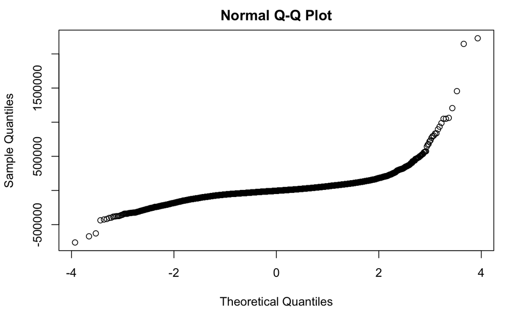

```r
qqnorm(model1$residuals)
```

## 3.2 Robust LM: M-estimation approach

```r
model2 <- MASS::rlm(trans_dwelling_price ~ trans_dwelling_floor_area, data = rema)
summary(model2)
```

```
Call: rlm(formula = trans_dwelling_price ~ trans_dwelling_floor_area,
    data = rema)
Residuals:
    Min      1Q  Median      3Q     Max
-703107  -37312   -3618   38634 2294234

Coefficients:
                          Value      Std. Error t value
(Intercept)               52619.8696  1558.1627    33.7705
trans_dwelling_floor_area  3981.0894    27.3950   145.3216

Residual standard error: 55910 on 11786 degrees of freedom
  (9 observations deleted due to missingness)
```

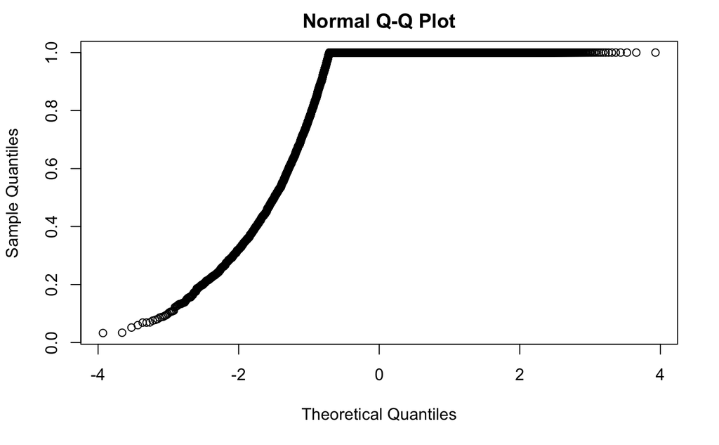

```r
qqnorm(model2$w) ## the weights used in the IWLS process
```

```r
plot(rema$trans_dwelling_floor_area,
     rema$trans_dwelling_price,
     xlab = 'Floor area',
     ylab = 'Price')
abline(coef(model1), col = 'red')
```

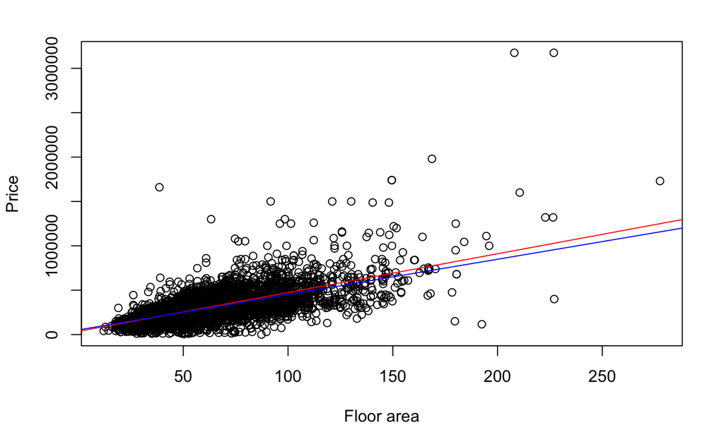

```r
abline(coef(model2), col = 'blue')
```

## 3.3 Robust LM: MM-estimation approach

```r
model3 <- MASS::rlm(trans_dwelling_price ~ trans_dwelling_floor_area,
                    data = rema, method = 'MM')
summary(model3)
```

```
Call: rlm(formula = trans_dwelling_price ~ trans_dwelling_floor_area,
    data = rema, method = "MM")
Residuals:
    Min      1Q  Median      3Q     Max
-687994  -36410   -2902   39652 2310872

Coefficients:
                          Value      Std. Error t value
(Intercept)               56431.7947  1539.2252    36.6625
trans_dwelling_floor_area  3882.7797    27.0621   143.4768

Residual standard error: 55940 on 11786 degrees of freedom
  (9 observations deleted due to missingness)
```

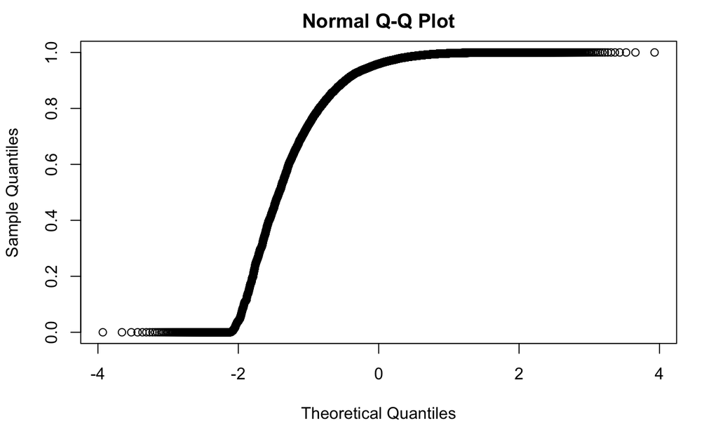

```r
qqnorm(model3$w) ## the weights used in the IWLS process
```

```r
model3 <- lmRob(trans_dwelling_price ~ trans_dwelling_floor_area,
              data = rema)
summary(model3)
```

```
Call:
lmRob(formula = trans_dwelling_price ~ trans_dwelling_floor_area,
    data = rema)

Residuals:
    Min      1Q  Median      3Q     Max
-692576  -36556   -3130   39307 2305823

Coefficients:
                          Estimate Std. Error t value Pr(>|t|)
(Intercept)               55224.12    1817.52   30.38   <2e-16 ***
trans_dwelling_floor_area  3912.86      33.98  115.14   <2e-16 ***
---
Signif. codes:  0 ‘***’ 0.001 ‘**’ 0.01 ‘*’ 0.05 ‘.’ 0.1 ‘ ’ 1

Residual standard error: 55260 on 11786 degrees of freedom
Multiple R-Squared: 0.3484

Test for Bias:
            statistic p-value
M-estimate      183.5       0
LS-estimate    2528.2       0
9 observations deleted due to missingness
```

The ‘test for bias’ is of the M-estimator against the initial S-estimator; if the M-estimator appears biased the initial S-estimator is returned.

```r
model4 <- lmrob(trans_dwelling_price ~ trans_dwelling_floor_area,
                data = rema)
summary(model4)
```

```
Call:
lmrob(formula = trans_dwelling_price ~ trans_dwelling_floor_area, data = rema)
 \--> method = "MM"
Residuals:
    Min      1Q  Median      3Q     Max
-688031  -36408   -2906   39653 2310832

Coefficients:
                          Estimate Std. Error t value Pr(>|t|)
(Intercept)               56422.59    2563.57   22.01   <2e-16 ***
trans_dwelling_floor_area  3883.02      58.08   66.86   <2e-16 ***
---
Signif. codes:  0 ‘***’ 0.001 ‘**’ 0.01 ‘*’ 0.05 ‘.’ 0.1 ‘ ’ 1

Robust residual standard error: 55950
Multiple R-squared:  0.5919,    Adjusted R-squared:  0.5919
Convergence in 23 IRWLS iterations

Robustness weights:
 199 observations c(22,25,40,72,93,94,95,123,124,197,206,222,261,269,276,305,339,344,384,442,443,450,451,555,573,574,606,627,675,710,718,861,864,928,1056,1082,1097,1103,1162,1251,1314,1440,1477,1567,1814,1841,1907,1943,1954,2112,2124,2157,2225,2285,2287,2367,2391,2400,2484,2485,2487,2537,2591,2779,2…
     are outliers with |weight| <= 4.8e-06 ( < 8.5e-06);
 1034 weights are ~= 1. The remaining 10555 ones are summarized as
     Min.   1st Qu.    Median      Mean   3rd Qu.      Max.
0.0000278 0.8445000 0.9516000 0.8696000 0.9865000 0.9990000
Algorithmic parameters:
       tuning.chi                bb        tuning.psi        refine.tol           rel.tol
        1.548e+00         5.000e-01         4.685e+00         1.000e-07         1.000e-07
        solve.tol       eps.outlier             eps.x warn.limit.reject warn.limit.meanrw
        1.000e-07         8.483e-06         5.049e-10         5.000e-01         5.000e-01
     nResample         max.it       best.r.s       k.fast.s          k.max    maxit.scale
           500             50              2              1            200            200
     trace.lev            mts     compute.rd fast.s.large.n
             0           1000              0           2000
                  psi           subsampling                   cov compute.outlier.stats
           "bisquare"         "nonsingular"         ".vcov.avar1"                  "SM"
seed : int(0)
```

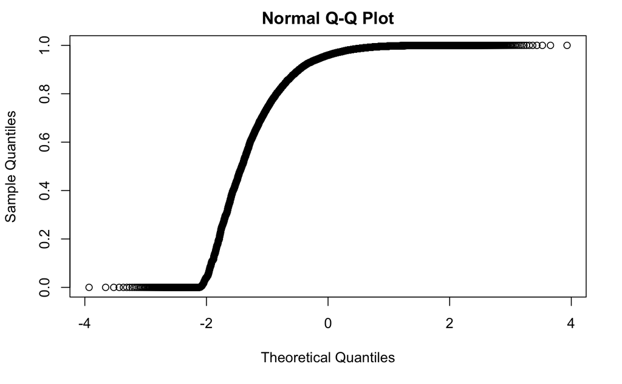

```r
qqnorm(model4$rweights)
```

## 3.4 ltsReg

```r
model5 <- robustbase::ltsReg(trans_dwelling_price ~ trans_dwelling_floor_area,
                            data = rema)
summary(model5)
```

```
Call:
ltsReg.formula(formula = trans_dwelling_price ~ trans_dwelling_floor_area,
    data = rema)

Residuals (from reweighted LS):
    Min      1Q  Median      3Q     Max
-141693  -27108       0   33022  141638

Coefficients:
                          Estimate Std. Error t value Pr(>|t|)
Intercept                 68912.19    1503.29   45.84   <2e-16 ***
trans_dwelling_floor_area  3517.46      27.98  125.72   <2e-16 ***
---
Signif. codes:  0 ‘***’ 0.001 ‘**’ 0.01 ‘*’ 0.05 ‘.’ 0.1 ‘ ’ 1

Residual standard error: 53970 on 10843 degrees of freedom
Multiple R-Squared: 0.5931, Adjusted R-squared: 0.5931
F-statistic: 1.581e+04 on 1 and 10843 DF,  p-value: < 2.2e-16
```